# Chapter 6

# Analysis of longitudinal data

## Part 1: Analysis of RATS data

### RATS data overview

RATS data consists of rat weight measurements over 9 weeks period. Rats were divided into three groups, where each group had individual nutrient diet. Aim of the study was to solve the differences between diets through weight development of study rats.

Data has total of 16 rats, divided somewhat equally to the diet groups. Group 1 had 8 obs. and other 2 groups had only 4.

```r
library(dplyr)
library(tidyr)
RATS <- read.table("https://raw.githubusercontent.com/KimmoVehkalahti/MABS/master/Examples/data/rats.txt", header = TRUE, sep = '\t')
RATS$ID <- factor(RATS$ID)
RATS$Group <- factor(RATS$Group)
names(RATS)
```

```
##  [1] "ID"    "Group" "WD1"   "WD8"   "WD15"  "WD22"  "WD29"  "WD36"
##  [9] "WD43"  "WD44"  "WD50"  "WD57"  "WD64"
```

```r
summary(RATS)
```

```
##        ID     Group      WD1             WD8             WD15
##  1      : 1   1:8   Min.   :225.0   Min.   :230.0   Min.   :230.0
##  2      : 1   2:4   1st Qu.:252.5   1st Qu.:255.0   1st Qu.:255.0
##  3      : 1   3:4   Median :340.0   Median :345.0   Median :347.5
##  4      : 1         Mean   :365.9   Mean   :369.1   Mean   :372.5
##  5      : 1         3rd Qu.:480.0   3rd Qu.:476.2   3rd Qu.:486.2
##  6      : 1         Max.   :555.0   Max.   :560.0   Max.   :565.0
##  (Other):10
##       WD22            WD29            WD36            WD43
##  Min.   :232.0   Min.   :240.0   Min.   :240.0   Min.   :243.0
##  1st Qu.:267.2   1st Qu.:268.8   1st Qu.:267.2   1st Qu.:269.2
##  Median :351.5   Median :356.5   Median :360.0   Median :360.0
##  Mean   :379.2   Mean   :383.9   Mean   :387.0   Mean   :386.0
##  3rd Qu.:492.5   3rd Qu.:497.8   3rd Qu.:504.2   3rd Qu.:501.0
##  Max.   :580.0   Max.   :590.0   Max.   :597.0   Max.   :595.0
##
##       WD44            WD50            WD57            WD64
##  Min.   :244.0   Min.   :238.0   Min.   :247.0   Min.   :245.0
##  1st Qu.:270.0   1st Qu.:273.8   1st Qu.:273.8   1st Qu.:278.0
##  Median :362.0   Median :370.0   Median :373.5   Median :378.0
##  Mean   :388.3   Mean   :394.6   Mean   :398.6   Mean   :404.1
##  3rd Qu.:510.5   3rd Qu.:516.0   3rd Qu.:524.5   3rd Qu.:530.8
##  Max.   :595.0   Max.   :612.0   Max.   :618.0   Max.   :628.0
##
```

```r
glimpse(RATS)
```

```
## Observations: 16
## Variables: 13
## $ ID    <fct> 1, 2, 3, 4, 5, 6, 7, 8, 9, 10, 11, 12, 13, 14, 15, 16
## $ Group <fct> 1, 1, 1, 1, 1, 1, 1, 1, 2, 2, 2, 2, 3, 3, 3, 3
## $ WD1   <int> 240, 225, 245, 260, 255, 260, 275, 245, 410, 405, 445, 5...
## $ WD8   <int> 250, 230, 250, 255, 260, 265, 275, 255, 415, 420, 445, 5...
## $ WD15  <int> 255, 230, 250, 255, 255, 270, 260, 260, 425, 430, 450, 5...
## $ WD22  <int> 260, 232, 255, 265, 270, 275, 270, 268, 428, 440, 452, 5...
## $ WD29  <int> 262, 240, 262, 265, 270, 275, 273, 270, 438, 448, 455, 5...
## $ WD36  <int> 258, 240, 265, 268, 273, 277, 274, 265, 443, 460, 455, 5...
## $ WD43  <int> 266, 243, 267, 270, 274, 278, 276, 265, 442, 458, 451, 5...
## $ WD44  <int> 266, 244, 267, 272, 273, 278, 271, 267, 446, 464, 450, 5...
## $ WD50  <int> 265, 238, 264, 274, 276, 284, 282, 273, 456, 475, 462, 6...
## $ WD57  <int> 272, 247, 268, 273, 278, 279, 281, 274, 468, 484, 466, 6...
## $ WD64  <int> 278, 245, 269, 275, 280, 281, 284, 278, 478, 496, 472, 6...
```

### Plot of individual rat growth profiles

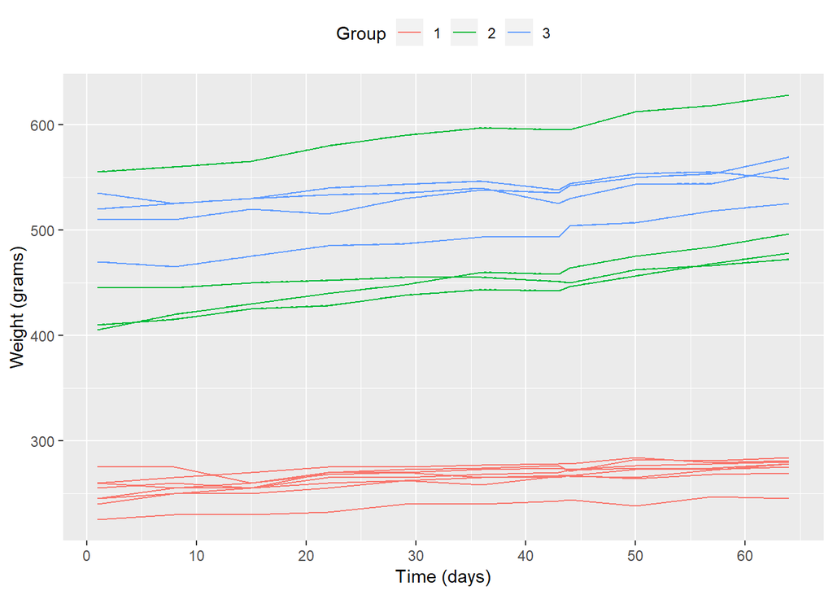

```r
library(dplyr)
library(tidyr)
library(ggplot2)

RATS <- read.table("https://raw.githubusercontent.com/KimmoVehkalahti/MABS/master/Examples/data/rats.txt", header = TRUE, sep = '\t')
RATS$ID <- factor(RATS$ID)
RATS$Group <- factor(RATS$Group)

RATSL <- RATS %>%
  gather(key = WD, value = Weight, -ID, -Group) %>%
  mutate(Time = as.integer(substr(WD,3,4)))
ggplot(RATSL, aes(x = Time, y = Weight, group = ID,color=Group)) +
  geom_line() +
  geom_line(aes(linetype = Group)) +
  scale_x_continuous(name = "Time (days)", breaks = seq(0, 60, 10)) +
  scale_y_continuous(name = "Weight (grams)") +
  theme(legend.position = "top")
```

**Note** From the individual rat growth profile, we are able to recognize that the diet group 1 are generally lighter, when compared to other two groups. Also, its easy to see that the rats in group 1 get weight much less than the rats in other groups.

### Scatterplot matrix of repeated measures in rat growth data

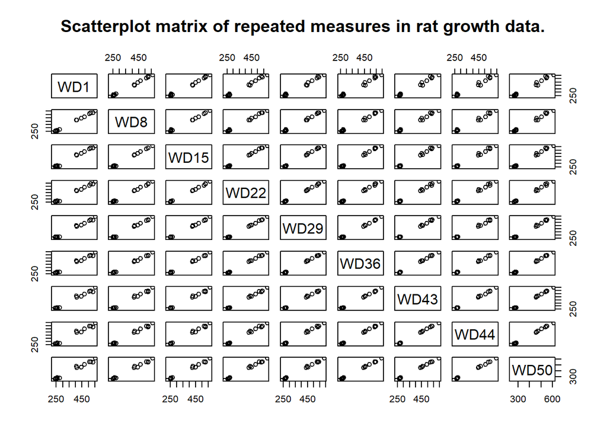

```r
RATS <- read.table("https://raw.githubusercontent.com/KimmoVehkalahti/MABS/master/Examples/data/rats.txt", header = TRUE, sep = '\t')
RATS$ID <- factor(RATS$ID)
RATS$Group <- factor(RATS$Group)

RATSL <- RATS %>%
  gather(key = WD, value = Weight, -ID, -Group) %>%
  mutate(Time = as.integer(substr(WD,3,4)))
pairs(RATS[,3:11],
   main="Scatterplot matrix of repeated measures in rat growth data.")
```

**Note** From scatterplot matrix we are able to recognize that there are dependencies between the measurements made at different points of time: this is of course obvious since the rats who are getting weight - will most likely get weight on upcoming measurements aswell

Longitudinal data, where a response variable is measured on each subject on several different occasions poses problems for their analysis because the repeated measurements on each subject are very likely to be correlated rather than independent. (MABS4IODS, part VI)

### Fitted growth rate profiles from the interaction model and observed growth rate profiles

Next we will create a random intercept and random slope model with the interaction (Group x Time Interaction to Rat Growth Data) and compare it to model without interaction (anova table).

```r
library(dplyr)
library(tidyr)
library(ggplot2)
library(lme4)
library(cowplot)
RATS <- read.table("https://raw.githubusercontent.com/KimmoVehkalahti/MABS/master/Examples/data/rats.txt", header = TRUE, sep = '\t')
RATS$ID <- factor(RATS$ID)
RATS$Group <- factor(RATS$Group)

RATSL <- RATS %>%
  gather(key = WD, value = Weight, -ID, -Group) %>%
  mutate(Time = as.integer(substr(WD,3,4)))

g1 <- ggplot(RATSL, aes(x = Time, y = Weight, group = ID, color=Group)) +
  geom_line(aes(linetype = Group)) +
  scale_x_continuous(name = "Time (days)", breaks = seq(0, 60, 20)) +
  scale_y_continuous(name = "Observed weight (grams)") +
  theme(legend.position = "top")

RATS_ref1 <- lmer(Weight ~ Time + Group + (Time | ID), data = RATSL, REML = FALSE)

RATS_ref2 <- lmer(Weight ~ Time * Group + (Time | ID), data = RATSL, REML = FALSE)
anova(RATS_ref2, RATS_ref1)
```

```
## Data: RATSL
## Models:
## RATS_ref1: Weight ~ Time + Group + (Time | ID)
## RATS_ref2: Weight ~ Time * Group + (Time | ID)
##           Df    AIC    BIC  logLik deviance  Chisq Chi Df Pr(>Chisq)
## RATS_ref1  8 1194.2 1219.6 -589.11   1178.2
## RATS_ref2 10 1185.9 1217.6 -582.93   1165.9 12.361      2    0.00207 **
## ---
## Signif. codes:  0 '***' 0.001 '**' 0.01 '*' 0.05 '.' 0.1 ' ' 1
```

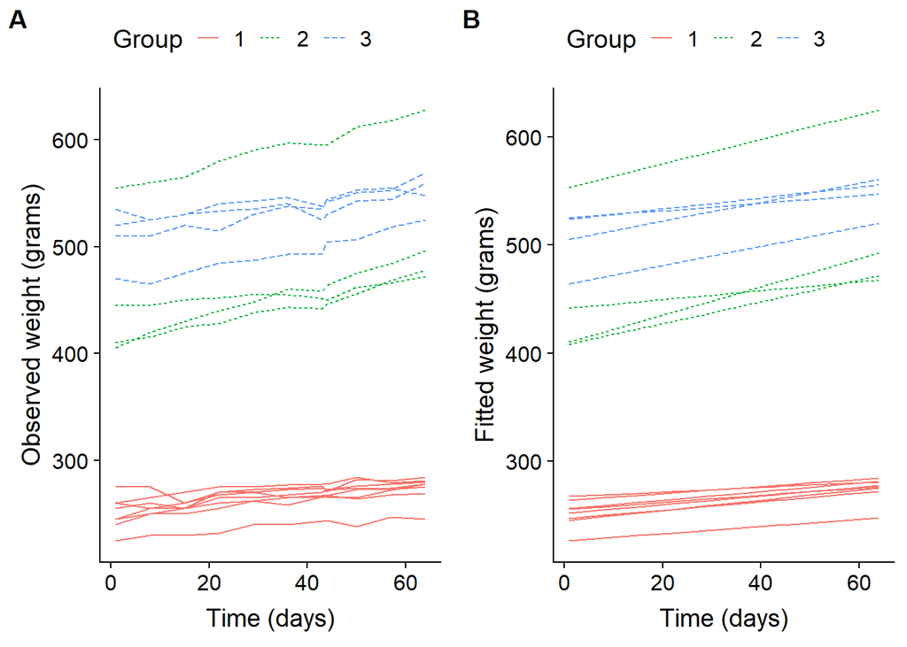

```r
Fitted <- fitted(RATS_ref2)

RATSL <- RATSL  %>%
  mutate(fitted = as.numeric(Fitted))

g2 <- ggplot(RATSL, aes(x = Time, y = fitted, group = ID, color=Group)) +
  geom_line(aes(linetype = Group)) +
  scale_x_continuous(name = "Time (days)", breaks = seq(0, 60, 20)) +
  scale_y_continuous(name = "Fitted weight (grams)") +
  theme(legend.position = "top")

plot_grid(g1, g2, labels = "AUTO")
```

**Note** From the Anova, we are able to conclude that interaction is 12.36 (Chisq Chi) with 2 DF; the associated p-value is very small, and we can conclude that the interaction model provides a better fit for the rat growth data (MABS4IODS)

Stat. signif. is 0.00207 **.

## Part 2: Analysis of BPRS data

### BPRS data overview

Likewise the earlier RATS data, BPRS (Brief Psychiatric Rating Scale?) data has measurements made over time. The data consists of 40 subjects who have been interviewed by doctors for 9 weeks (one measurement each week). Measurements are presented by bprs-value.

Below is the summary of the dataframe.

```r
BPRS <- read.table("https://raw.githubusercontent.com/KimmoVehkalahti/MABS/master/Examples/data/BPRS.txt", sep  =" ", header = T)

names(BPRS)
```

```
##  [1] "treatment" "subject"   "week0"     "week1"     "week2"
##  [6] "week3"     "week4"     "week5"     "week6"     "week7"
## [11] "week8"
```

```r
dim(BPRS)
```

```
## [1] 40 11
```

```r
summary(BPRS)
```

```
##    treatment      subject          week0           week1
##  Min.   :1.0   Min.   : 1.00   Min.   :24.00   Min.   :23.00
##  1st Qu.:1.0   1st Qu.: 5.75   1st Qu.:38.00   1st Qu.:35.00
##  Median :1.5   Median :10.50   Median :46.00   Median :41.00
##  Mean   :1.5   Mean   :10.50   Mean   :48.00   Mean   :46.33
##  3rd Qu.:2.0   3rd Qu.:15.25   3rd Qu.:58.25   3rd Qu.:54.25
##  Max.   :2.0   Max.   :20.00   Max.   :78.00   Max.   :95.00
##      week2          week3           week4           week5
##  Min.   :26.0   Min.   :24.00   Min.   :20.00   Min.   :20.00
##  1st Qu.:32.0   1st Qu.:29.75   1st Qu.:28.00   1st Qu.:26.00
##  Median :38.0   Median :36.50   Median :34.50   Median :30.50
##  Mean   :41.7   Mean   :39.15   Mean   :36.35   Mean   :32.55
##  3rd Qu.:49.0   3rd Qu.:44.50   3rd Qu.:43.00   3rd Qu.:38.00
##  Max.   :75.0   Max.   :76.00   Max.   :66.00   Max.   :64.00
##      week6           week7          week8
##  Min.   :19.00   Min.   :18.0   Min.   :20.00
##  1st Qu.:22.75   1st Qu.:23.0   1st Qu.:22.75
##  Median :28.50   Median :30.0   Median :28.00
##  Mean   :31.23   Mean   :32.2   Mean   :31.43
##  3rd Qu.:37.00   3rd Qu.:38.0   3rd Qu.:35.25
##  Max.   :64.00   Max.   :62.0   Max.   :75.00
```

### Individual response profiles by treatment group for the BPRS data

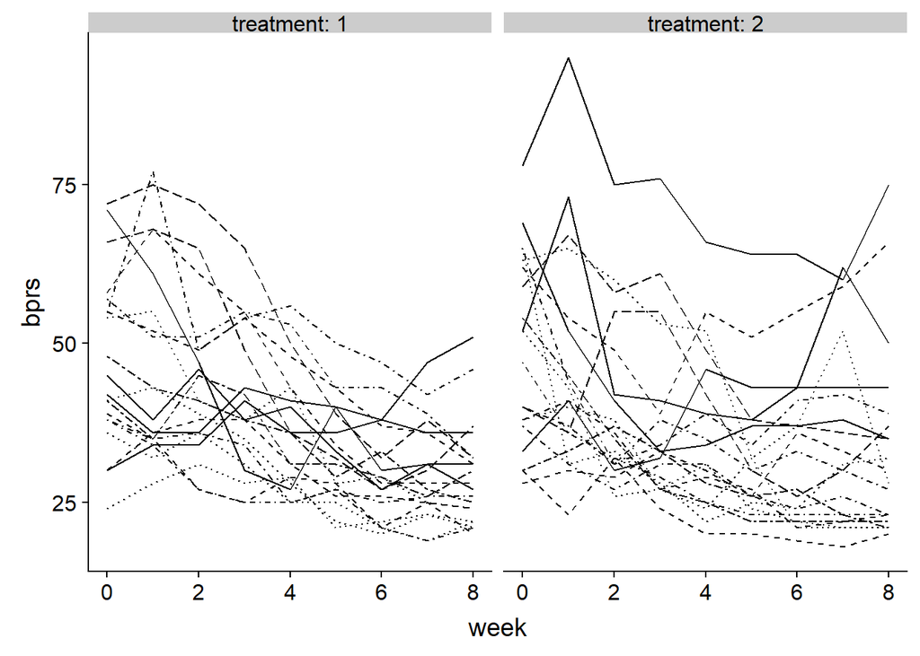

```r
library(dplyr)
library(tidyr)
library(ggplot2)
BPRS <- read.table("https://raw.githubusercontent.com/KimmoVehkalahti/MABS/master/Examples/data/BPRS.txt", sep  =" ", header = T)
BPRS$treatment <- factor(BPRS$treatment)
BPRS$subject <- factor(BPRS$subject)
BPRSL <-  BPRS %>% gather(key = weeks, value = bprs, -treatment, -subject)
BPRSL <-  BPRSL %>% mutate(week = as.integer(substr(weeks,5,6)))
ggplot(BPRSL, aes(x = week, y = bprs, linetype = subject)) +
  geom_line() +
  scale_linetype_manual(values = rep(1:10, times=4)) +
  facet_grid(. ~ treatment, labeller = label_both) +
  theme(legend.position = "none") +
  scale_y_continuous(limits = c(min(BPRSL$bprs), max(BPRSL$bprs)))
```

### Individual response profiles for BPRS data after standardization.

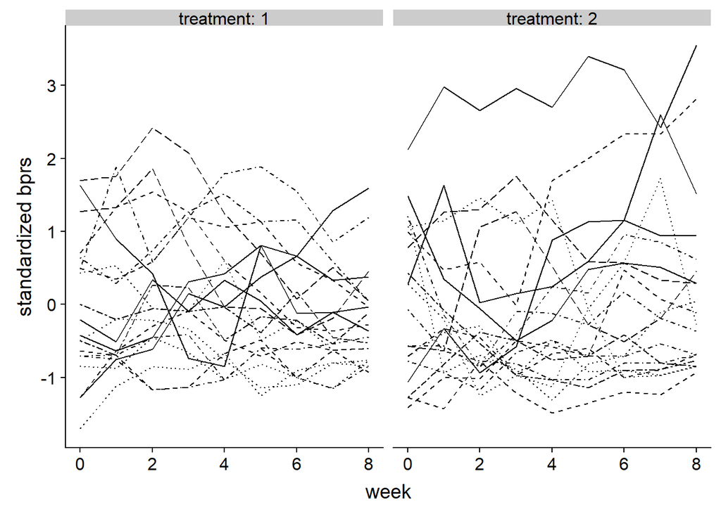

```r
library(dplyr)
library(tidyr)
library(ggplot2)
BPRS <- read.table("https://raw.githubusercontent.com/KimmoVehkalahti/MABS/master/Examples/data/BPRS.txt", sep  =" ", header = T)
BPRS$treatment <- factor(BPRS$treatment)
BPRS$subject <- factor(BPRS$subject)
BPRSL <-  BPRS %>% gather(key = weeks, value = bprs, -treatment, -subject)
BPRSL <-  BPRSL %>% mutate(week = as.integer(substr(weeks,5,6)))

BPRSL <- BPRSL %>%
  group_by(week) %>%
  mutate(stdbprs = as.numeric(scale(bprs))) %>%
  ungroup()
ggplot(BPRSL, aes(x = week, y = stdbprs, linetype = subject)) +
  geom_line() +
  scale_linetype_manual(values = rep(1:10, times=4)) +
  facet_grid(. ~ treatment, labeller = label_both) +
  theme(legend.position = "none") +
  scale_y_continuous(name = "standardized bprs")
```

**Note** The tracking phenomenom can be seen from the standardized values of each observation. There are substantial individual differences and variability appears to decrease with time. (MABS4IODS)

### Mean response profiles for the two treatment groups in the BPRS data

Better way to graphically represent the differences between observations, is to plot average profiles of each treatment group.

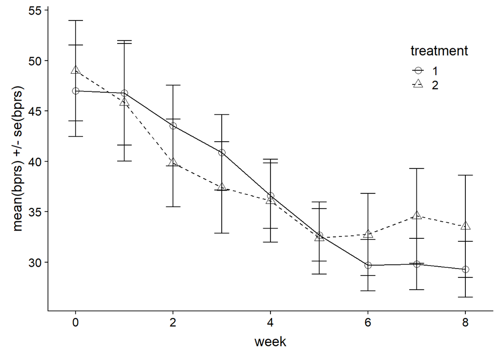

```r
BPRS <- read.table("https://raw.githubusercontent.com/KimmoVehkalahti/MABS/master/Examples/data/BPRS.txt", sep  =" ", header = T)
BPRS$treatment <- factor(BPRS$treatment)
BPRS$subject <- factor(BPRS$subject)
BPRSL <-  BPRS %>% gather(key = weeks, value = bprs, -treatment, -subject)
BPRSL <-  BPRSL %>% mutate(week = as.integer(substr(weeks,5,6)))
BPRSL <- BPRSL %>%
  group_by(week) %>%
  mutate(stdbprs = as.numeric(scale(bprs))) %>%
  ungroup()
n <- BPRSL$week %>% unique() %>% length()

BPRSS <- BPRSL %>%
  group_by(treatment, week) %>%
  summarise(mean = mean(bprs), se = sd(bprs)/sqrt(n)) %>%
  ungroup()
ggplot(BPRSS, aes(x = week, y = mean, linetype = treatment, shape = treatment)) +
  geom_line() +
  scale_linetype_manual(values = c(1,2)) +
  geom_point(size=3) +
  scale_shape_manual(values = c(1,2)) +
  geom_errorbar(aes(ymin=mean-se, ymax=mean+se, linetype="1"), width=0.3) +
  theme(legend.position = c(0.8,0.8)) +
  scale_y_continuous(name = "mean(bprs) +/- se(bprs)")
```

### Boxplots for the BPRS data

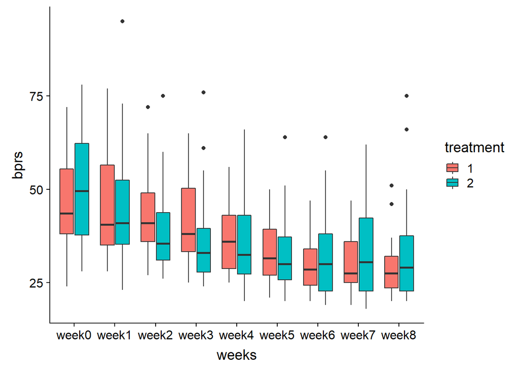

```r
BPRS <- read.table("https://raw.githubusercontent.com/KimmoVehkalahti/MABS/master/Examples/data/BPRS.txt", sep  =" ", header = T)
BPRS$treatment <- factor(BPRS$treatment)
BPRS$subject <- factor(BPRS$subject)
BPRSL <-  BPRS %>% gather(key = weeks, value = bprs, -treatment, -subject)
BPRSL <-  BPRSL %>% mutate(week = as.integer(substr(weeks,5,6)))
BPRSL <- BPRSL %>%
  group_by(week) %>%
  mutate(stdbprs = as.numeric(scale(bprs))) %>%
  ungroup()
n <- BPRSL$week %>% unique() %>% length()

BPRSS <- BPRSL %>%
  group_by(treatment, week) %>%
  summarise(mean = mean(bprs), se = sd(bprs)/sqrt(n)) %>%
  ungroup()
ggplot(data = BPRSL, aes(x=weeks, y=bprs)) + geom_boxplot(aes(fill=treatment))
```

**Note** Mean profiles can be graphically shown as boxplots where treatment groups are side-by-side. Plot clearly shows that there might exist differences between the treatment groups and outliers (points). Also, there is clear decline in bprs-values over time. Treatments seem to be working for patients.

### Boxplot of the mean versus treatment

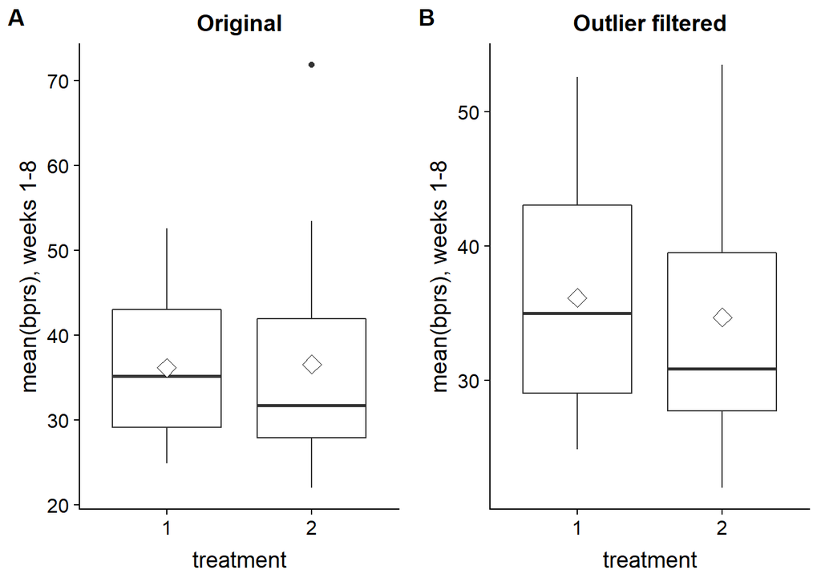

```r
library(dplyr)
library(tidyr)
library(ggplot2)
library(lme4)
library(cowplot)
BPRS <- read.table("https://raw.githubusercontent.com/KimmoVehkalahti/MABS/master/Examples/data/BPRS.txt", sep  =" ", header = T)
BPRS$treatment <- factor(BPRS$treatment)
BPRS$subject <- factor(BPRS$subject)
BPRSL <-  BPRS %>% gather(key = weeks, value = bprs, -treatment, -subject)
BPRSL <-  BPRSL %>% mutate(week = as.integer(substr(weeks,5,6)))
BPRSL <- BPRSL %>%
  group_by(week) %>%
  mutate(stdbprs = as.numeric(scale(bprs))) %>%
  ungroup()
n <- BPRSL$week %>% unique() %>% length()
BPRSS <- BPRSL %>%
  group_by(treatment, week) %>%
  summarise(mean = mean(bprs), se = sd(bprs)/sqrt(n)) %>%
  ungroup()

BPRSL8S <- BPRSL %>%
  filter(week > 0) %>%
  group_by(treatment, subject) %>%
  summarise( mean=mean(bprs) ) %>%
  ungroup()
g1 <- ggplot(BPRSL8S, aes(x = treatment, y = mean)) +
  geom_boxplot() +
  ggtitle("Original")+
  stat_summary(fun.y = "mean", geom = "point", shape=23, size=4, fill = "white") +
  scale_y_continuous(name = "mean(bprs), weeks 1-8")
BPRSL8S1 <- BPRSL8S  %>%
  filter(subject != 11)

g2 <- ggplot(BPRSL8S1, aes(x = treatment, y = mean)) +
  geom_boxplot() +
  ggtitle("Outlier filtered")+
  stat_summary(fun.y = "mean", geom = "point", shape=23, size=4, fill = "white") +
  scale_y_continuous(name = "mean(bprs), weeks 1-8")
plot_grid(g1, g2, labels = "AUTO")
```

### T-test and Anova (with baseline)

```r
BPRS <- read.table("https://raw.githubusercontent.com/KimmoVehkalahti/MABS/master/Examples/data/BPRS.txt", sep  =" ", header = T)
BPRS$treatment <- factor(BPRS$treatment)
BPRS$subject <- factor(BPRS$subject)
BPRSL <-  BPRS %>% gather(key = weeks, value = bprs, -treatment, -subject)
BPRSL <-  BPRSL %>% mutate(week = as.integer(substr(weeks,5,6)))
BPRSL <- BPRSL %>%
  group_by(week) %>%
  mutate(stdbprs = as.numeric(scale(bprs))) %>%
  ungroup()
n <- BPRSL$week %>% unique() %>% length()
BPRSS <- BPRSL %>%
  group_by(treatment, week) %>%
  summarise(mean = mean(bprs), se = sd(bprs)/sqrt(n)) %>%
  ungroup()

BPRSL8S <- BPRSL %>%
  filter(week > 0) %>%
  group_by(treatment, subject) %>%
  summarise( mean=mean(bprs) ) %>%
  ungroup()

t.test(mean ~ treatment, data = BPRSL8S1, var.equal = TRUE)
```

```
##
##  Two Sample t-test
##
## data:  mean by treatment
## t = 0.50364, df = 36, p-value = 0.6176
## alternative hypothesis: true difference in means is not equal to 0
## 95 percent confidence interval:
##  -4.400946  7.308841
## sample estimates:
## mean in group 1 mean in group 2
##        36.15789        34.70395
```

```r
# Add the baseline from the original data as a new variable to the summary data
BPRSL8S2 <- BPRSL8S %>%
  mutate(baseline = BPRS$week0)

# Fit the linear model with the mean as the response
fit <- lm(mean ~ baseline + treatment, data = BPRSL8S2)

# Compute the analysis of variance table for the fitted model with anova()
anova = anova(fit)
anova
```

```
## Analysis of Variance Table
##
## Response: mean
##           Df  Sum Sq Mean Sq F value    Pr(>F)
## baseline   1 1868.07 1868.07 30.1437 3.077e-06 ***
## treatment  1    3.45    3.45  0.0557    0.8148
## Residuals 37 2292.97   61.97
## ---
## Signif. codes:  0 '***' 0.001 '**' 0.01 '*' 0.05 '.' 0.1 ' ' 1
```

T-test shatters my earlier conclusion (boxplots) that there would be statistical differences between the treatment groups. p-value = 0.6176

From Anova-table we are able to recognize that bprs-values of each subject are strongly correlated with the baseline (week 0) bprs-values. Although, there is no statistical significance between the treatment groups. p-value is 0.8148.